# 004. 網絡分析（二）：分析範例

## 合併actors資料與與網絡資料

```r
V(fauxhs.net)$name
```

```
##   [1] "1"   "2"   "3"   "4"   "5"   "6"   "7"   "8"   "9"   "10"  "11"  "12"
##  [13] "13"  "14"  "15"  "16"  "17"  "18"  "19"  "20"  "21"  "22"  "23"  "24"
##  [25] "25"  "26"  "27"  "28"  "29"  "30"  "31"  "32"  "33"  "34"  "35"  "36"
##  [37] "37"  "38"  "39"  "40"  "41"  "42"  "43"  "44"  "45"  "46"  "47"  "48"
##  [49] "49"  "50"  "51"  "52"  "53"  "54"  "55"  "56"  "57"  "58"  "59"  "60"
##  [61] "61"  "62"  "63"  "64"  "65"  "66"  "67"  "68"  "69"  "70"  "71"  "72"
##  [73] "73"  "74"  "75"  "76"  "77"  "78"  "79"  "80"  "81"  "82"  "83"  "84"
##  [85] "85"  "86"  "87"  "88"  "89"  "90"  "91"  "92"  "93"  "94"  "95"  "96"
##  [97] "97"  "98"  "99"  "100" "101" "102" "103" "104" "105" "106" "107" "108"
## [109] "109" "110" "111" "112" "113" "114" "115" "116" "117" "118" "119" "120"
```

```r
V(fauxhs.eg)$name
```

```
##   [1] "14"  "26"  "31"  "39"  "50"  "53"  "54"  "56"  "63"  "71"  "86"  "92"
##  [13] "98"  "74"  "108" "119" "16"  "59"  "91"  "11"  "28"  "66"  "120" "23"
##  [25] "41"  "34"  "87"  "13"  "29"  "43"  "107" "21"  "79"  "35"  "72"  "90"
##  [37] "112" "32"  "58"  "36"  "68"  "22"  "33"  "44"  "82"  "25"  "65"  "104"
##  [49] "100" "106" "116" "75"  "46"  "60"  "78"  "109" "117" "48"  "38"  "49"
##  [61] "89"  "40"  "84"  "37"  "114" "47"  "99"  "76"  "55"  "61"  "93"  "97"
##  [73] "51"  "88"  "101" "103" "85"  "67"  "80"  "77"  "81"  "113" "118" "102"
##  [85] "110" "111" "94"  "105" "96"  "95"  "115" "1"   "2"   "3"   "4"   "5"
##  [97] "6"   "7"   "8"   "9"   "10"  "12"  "15"  "17"  "18"  "19"  "20"  "24"
## [109] "27"  "30"  "42"  "45"  "52"  "57"  "62"  "64"  "69"  "70"  "73"  "83"
```

```r
V(fauxhs.net)$gpa <- fauxhs[match(V(fauxhs.net)$name, fauxhs$ids ), "gpa"]
V(fauxhs.net)$grade <- factor(fauxhs[match(V(fauxhs.net)$name, fauxhs$ids ), "grade"])
V(fauxhs.net)$gender <- factor(fauxhs[match(V(fauxhs.net)$name, fauxhs$ids ), "gender"])
V(fauxhs.net)$race <- factor(fauxhs[match(V(fauxhs.net)$name, fauxhs$ids ), "race"])
```

**以grade分類**  
可以發現grade為7~12的整數

```r
fauxhs$grade
summary(fauxhs$grade)
```

```r
fauxhs$grade
```

```
##   [1]  7  7 10 11  9  9  9  8 10  7 10 12  8  7  8 11  7  9 12 10 10  7 12 10  8
##  [26]  7 11  9  8  7 12 11  7 11  7  8 11  8  7  7 12 10  8  7  7  9  8 11  8  7
##  [51]  7 10  7  7  9  7  9 12 11  8  9  9  7  7  7  9  8  8 11  7  7  7  7  7 11
##  [76]  7  7  8 12  9 11  7 10  9  7  7  9  7  8  7 11  7  9  9 11  9  9  7 12  9
## [101]  7  7  7  7 10 10  8  7 10  8 10  7  7  7  9 10 12 11 10  9
```

```r
summary(fauxhs$grade)
```

```
##    Min. 1st Qu.  Median    Mean 3rd Qu.    Max.
##   7.000   7.000   8.000   8.708  10.000  12.000
```

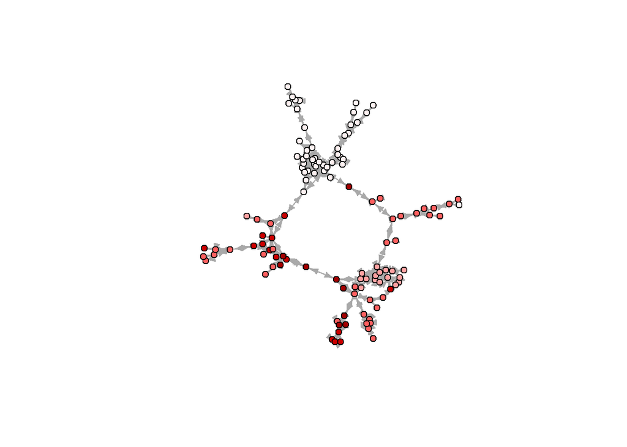

```r
V(fauxhs.net)$color <- c("#FFF2F2", "#FFA1A1", "#FF5F5F", "#FF5F5F", "#CC0000", "#A30000")[as.numeric(V(fauxhs.net)$grade)]
plot(fauxhs.net, vertex.size=5, vertex.label="", edge.arrow.size=0.5, layout = fauxhs.layout)
```

**以gender分類**  
R的排列方式為由小到大，由A~Z，因此若變項為文字，例如gender的F、M，則F會在前，因此下圖red=female，blue=man

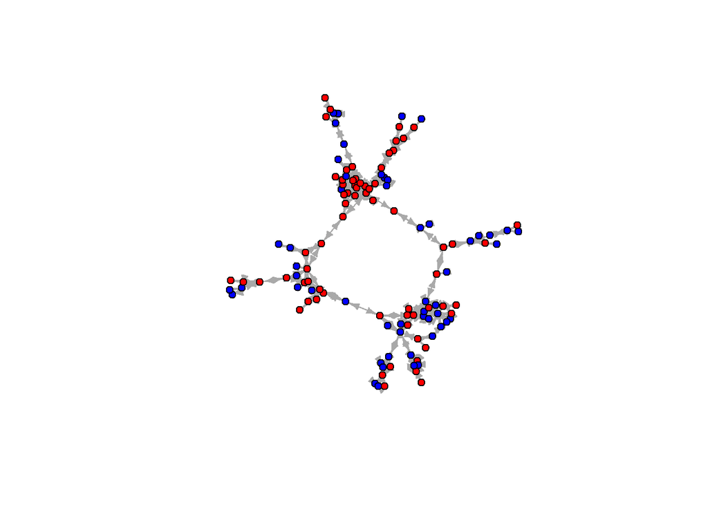

```r
V(fauxhs.net)$color=c("red", "blue")[as.numeric(V(fauxhs.net)$gender)]
plot(fauxhs.net, vertex.size=5, vertex.label="", edge.arrow.size=0.5, layout = fauxhs.layout)
```

## 計算網絡的詳細資訊

- Degree

```r
deg <- degree(fauxhs.net, mode = "all")
deg
```

```
##   1   2   3   4   5   6   7   8   9  10  11  12  13  14  15  16  17  18  19  20
##  26   8   2   6   8   4   4   8   4   8   2   6  12  14   4   8   4   2   2   4
##  21  22  23  24  25  26  27  28  29  30  31  32  33  34  35  36  37  38  39  40
##   2   6   6  18   6   8   4   6  18   4   4   6   4   6   4  10   4   8   6   2
##  41  42  43  44  45  46  47  48  49  50  51  52  53  54  55  56  57  58  59  60
##  10   4   4   4   2  10   2   4   2  20   4   2   8  14   6  10   2   8  10   4
##  61  62  63  64  65  66  67  68  69  70  71  72  73  74  75  76  77  78  79  80
##   6   4  10   2   6   6   2  14   6   2  10   6   4   6  10   8   6  12  10   6
##  81  82  83  84  85  86  87  88  89  90  91  92  93  94  95  96  97  98  99 100
##   2   2   2   6   8   4   6   2   8   8  16   6   6   8   2   2   8   2   2   6
## 101 102 103 104 105 106 107 108 109 110 111 112 113 114 115 116 117 118 119 120
##   8   2   6  10   2   8  14   8   4   2   6   6   4   2   2   2   4   2   6   2
```

- Out Degree

```r
outdeg <- degree(fauxhs.net, mode = "out")
outdeg
```

```
##   1   2   3   4   5   6   7   8   9  10  11  12  13  14  15  16  17  18  19  20
##  13   4   1   3   4   2   2   4   2   4   1   3   6   7   2   4   2   1   1   2
##  21  22  23  24  25  26  27  28  29  30  31  32  33  34  35  36  37  38  39  40
##   1   3   3   9   3   4   2   3   9   2   2   3   2   3   2   5   2   4   3   1
##  41  42  43  44  45  46  47  48  49  50  51  52  53  54  55  56  57  58  59  60
##   5   2   2   2   1   5   1   2   1  10   2   1   4   7   3   5   1   4   5   2
##  61  62  63  64  65  66  67  68  69  70  71  72  73  74  75  76  77  78  79  80
##   3   2   5   1   3   3   1   7   3   1   5   3   2   3   5   4   3   6   5   3
##  81  82  83  84  85  86  87  88  89  90  91  92  93  94  95  96  97  98  99 100
##   1   1   1   3   4   2   3   1   4   4   8   3   3   4   1   1   4   1   1   3
## 101 102 103 104 105 106 107 108 109 110 111 112 113 114 115 116 117 118 119 120
##   4   1   3   5   1   4   7   4   2   1   3   3   2   1   1   1   2   1   3   1
```

- In Degree

```r
indeg <- degree(fauxhs.net, mode = "in")
indeg
```

```
##   1   2   3   4   5   6   7   8   9  10  11  12  13  14  15  16  17  18  19  20
##  13   4   1   3   4   2   2   4   2   4   1   3   6   7   2   4   2   1   1   2
##  21  22  23  24  25  26  27  28  29  30  31  32  33  34  35  36  37  38  39  40
##   1   3   3   9   3   4   2   3   9   2   2   3   2   3   2   5   2   4   3   1
##  41  42  43  44  45  46  47  48  49  50  51  52  53  54  55  56  57  58  59  60
##   5   2   2   2   1   5   1   2   1  10   2   1   4   7   3   5   1   4   5   2
##  61  62  63  64  65  66  67  68  69  70  71  72  73  74  75  76  77  78  79  80
##   3   2   5   1   3   3   1   7   3   1   5   3   2   3   5   4   3   6   5   3
##  81  82  83  84  85  86  87  88  89  90  91  92  93  94  95  96  97  98  99 100
##   1   1   1   3   4   2   3   1   4   4   8   3   3   4   1   1   4   1   1   3
## 101 102 103 104 105 106 107 108 109 110 111 112 113 114 115 116 117 118 119 120
##   4   1   3   5   1   4   7   4   2   1   3   3   2   1   1   1   2   1   3   1
```

- Betweenness

```r
betweenness <- betweenness(fauxhs.net, normalized=T)
betweenness
```

```
##            1            2            3            4            5            6
## 5.215720e-01 6.556521e-03 0.000000e+00 0.000000e+00 3.347102e-02 0.000000e+00
##            7            8            9           10           11           12
## 5.501353e-03 1.321885e-02 1.680672e-02 3.354223e-02 0.000000e+00 1.995480e-01
##           13           14           15           16           17           18
## 2.693077e-02 6.601624e-02 0.000000e+00 9.656744e-02 0.000000e+00 0.000000e+00
##           19           20           21           22           23           24
## 0.000000e+00 1.680672e-02 0.000000e+00 7.121493e-05 2.848597e-04 2.647708e-01
##           25           26           27           28           29           30
## 2.848597e-04 7.752253e-03 0.000000e+00 8.118502e-02 8.261898e-02 1.680672e-02
##           31           32           33           34           35           36
## 2.902683e-01 3.745905e-02 0.000000e+00 1.147866e-02 1.680672e-02 1.670329e-02
##           37           38           39           40           41           42
## 0.000000e+00 1.701325e-02 1.264777e-01 0.000000e+00 1.128044e-01 4.956559e-02
##           43           44           45           46           47           48
## 0.000000e+00 0.000000e+00 0.000000e+00 8.146988e-02 0.000000e+00 0.000000e+00
##           49           50           51           52           53           54
## 0.000000e+00 5.780041e-02 0.000000e+00 0.000000e+00 4.747662e-04 6.985710e-02
##           55           56           57           58           59           60
## 0.000000e+00 5.663893e-02 0.000000e+00 1.977311e-01 4.101980e-02 0.000000e+00
##           61           62           63           64           65           66
## 1.680672e-02 1.680672e-02 1.686607e-02 0.000000e+00 1.424299e-04 1.680672e-02
##           67           68           69           70           71           72
## 0.000000e+00 2.894922e-01 2.287461e-01 0.000000e+00 4.240849e-02 3.332859e-02
##           73           74           75           76           77           78
## 9.656744e-02 6.072259e-03 4.985045e-02 1.697289e-02 1.680672e-02 9.225504e-02
##           79           80           81           82           83           84
## 1.844504e-01 3.332859e-02 0.000000e+00 0.000000e+00 0.000000e+00 2.955382e-01
##           85           86           87           88           89           90
## 1.118786e-01 0.000000e+00 2.751151e-02 0.000000e+00 6.775252e-03 7.199829e-02
##           91           92           93           94           95           96
## 2.693386e-01 2.329359e-01 0.000000e+00 3.479524e-01 0.000000e+00 0.000000e+00
##           97           98           99          100          101          102
## 2.848597e-04 0.000000e+00 0.000000e+00 2.750283e-01 1.203770e-02 0.000000e+00
##          103          104          105          106          107          108
## 3.691307e-03 8.189717e-02 0.000000e+00 1.136590e-01 1.507762e-01 2.254088e-02
##          109          110          111          112          113          114
## 0.000000e+00 0.000000e+00 1.680672e-02 2.392822e-02 2.848597e-04 0.000000e+00
##          115          116          117          118          119          120
## 0.000000e+00 0.000000e+00 0.000000e+00 0.000000e+00 3.347102e-02 0.000000e+00
```

- Closeness

```r
closeness <- closeness(fauxhs.net)
closeness
```

```
##            1            2            3            4            5            6
## 0.0017271157 0.0013679891 0.0009354537 0.0013986014 0.0010764263 0.0010952903
##            7            8            9           10           11           12
## 0.0011862396 0.0013404826 0.0013513514 0.0011160714 0.0009551098 0.0015748031
##           13           14           15           16           17           18
## 0.0014534884 0.0014662757 0.0011876485 0.0014104372 0.0009149131 0.0013351135
##           19           20           21           22           23           24
## 0.0013477089 0.0011890606 0.0011655012 0.0012531328 0.0011001100 0.0014450867
##           25           26           27           28           29           30
## 0.0011933174 0.0014684288 0.0009765625 0.0012239902 0.0013793103 0.0009871668
##           31           32           33           34           35           36
## 0.0016806723 0.0014641288 0.0012515645 0.0012195122 0.0009881423 0.0013947001
##           37           38           39           40           41           42
## 0.0013550136 0.0012210012 0.0014684288 0.0008841733 0.0012562814 0.0011947431
##           43           44           45           46           47           48
## 0.0012422360 0.0012515645 0.0011185682 0.0012500000 0.0010672359 0.0009765625
##           49           50           51           52           53           54
## 0.0011862396 0.0015015015 0.0012804097 0.0011862396 0.0014619883 0.0015037594
##           55           56           57           58           59           60
## 0.0010917031 0.0014925373 0.0009680542 0.0015384615 0.0014880952 0.0013422819
##           61           62           63           64           65           66
## 0.0010928962 0.0012820513 0.0014814815 0.0009140768 0.0009165903 0.0010752688
##           67           68           69           70           71           72
## 0.0011135857 0.0015923567 0.0016447368 0.0009354537 0.0014903130 0.0011148272
##           73           74           75           76           77           78
## 0.0011520737 0.0012755102 0.0011025358 0.0012886598 0.0009165903 0.0014836795
##           79           80           81           82           83           84
## 0.0016025641 0.0015060241 0.0009541985 0.0012500000 0.0012562814 0.0016393443
##           85           86           87           88           89           90
## 0.0013123360 0.0014534884 0.0012515645 0.0012755102 0.0013623978 0.0012722646
##           91           92           93           94           95           96
## 0.0016474465 0.0016611296 0.0010917031 0.0016103060 0.0013793103 0.0010905125
##           97           98           99          100          101          102
## 0.0010940919 0.0014347202 0.0010940919 0.0015847861 0.0013054830 0.0008271299
##          103          104          105          106          107          108
## 0.0013623978 0.0010245902 0.0013736264 0.0013793103 0.0015432099 0.0014430014
##          109          110          111          112          113          114
## 0.0013404826 0.0012626263 0.0014749263 0.0012674271 0.0011402509 0.0008849558
##          115          116          117          118          119          120
## 0.0013531800 0.0010427529 0.0013477089 0.0009756098 0.0010515247 0.0009551098
```

- Closeness（僅接收）

```r
closeness1 <- closeness(fauxhs.net, mode="in")
closeness1
```

```
##            1            2            3            4            5            6
## 0.0017271157 0.0013679891 0.0009354537 0.0013986014 0.0010764263 0.0010952903
##            7            8            9           10           11           12
## 0.0011862396 0.0013404826 0.0013513514 0.0011160714 0.0009551098 0.0015748031
##           13           14           15           16           17           18
## 0.0014534884 0.0014662757 0.0011876485 0.0014104372 0.0009149131 0.0013351135
##           19           20           21           22           23           24
## 0.0013477089 0.0011890606 0.0011655012 0.0012531328 0.0011001100 0.0014450867
##           25           26           27           28           29           30
## 0.0011933174 0.0014684288 0.0009765625 0.0012239902 0.0013793103 0.0009871668
##           31           32           33           34           35           36
## 0.0016806723 0.0014641288 0.0012515645 0.0012195122 0.0009881423 0.0013947001
##           37           38           39           40           41           42
## 0.0013550136 0.0012210012 0.0014684288 0.0008841733 0.0012562814 0.0011947431
##           43           44           45           46           47           48
## 0.0012422360 0.0012515645 0.0011185682 0.0012500000 0.0010672359 0.0009765625
##           49           50           51           52           53           54
## 0.0011862396 0.0015015015 0.0012804097 0.0011862396 0.0014619883 0.0015037594
##           55           56           57           58           59           60
## 0.0010917031 0.0014925373 0.0009680542 0.0015384615 0.0014880952 0.0013422819
##           61           62           63           64           65           66
## 0.0010928962 0.0012820513 0.0014814815 0.0009140768 0.0009165903 0.0010752688
##           67           68           69           70           71           72
## 0.0011135857 0.0015923567 0.0016447368 0.0009354537 0.0014903130 0.0011148272
##           73           74           75           76           77           78
## 0.0011520737 0.0012755102 0.0011025358 0.0012886598 0.0009165903 0.0014836795
##           79           80           81           82           83           84
## 0.0016025641 0.0015060241 0.0009541985 0.0012500000 0.0012562814 0.0016393443
##           85           86           87           88           89           90
## 0.0013123360 0.0014534884 0.0012515645 0.0012755102 0.0013623978 0.0012722646
##           91           92           93           94           95           96
## 0.0016474465 0.0016611296 0.0010917031 0.0016103060 0.0013793103 0.0010905125
##           97           98           99          100          101          102
## 0.0010940919 0.0014347202 0.0010940919 0.0015847861 0.0013054830 0.0008271299
##          103          104          105          106          107          108
## 0.0013623978 0.0010245902 0.0013736264 0.0013793103 0.0015432099 0.0014430014
##          109          110          111          112          113          114
## 0.0013404826 0.0012626263 0.0014749263 0.0012674271 0.0011402509 0.0008849558
##          115          116          117          118          119          120
## 0.0013531800 0.0010427529 0.0013477089 0.0009756098 0.0010515247 0.0009551098
```

- 計算其他信息

```r
eigen <- eigen_centrality(fauxhs.net)
eigen
```

```
## $vector
##            1            2            3            4            5            6
## 1.000000e+00 2.033687e-01 9.643995e-06 4.082627e-03 1.978150e-04 1.466045e-05
##            7            8            9           10           11           12
## 2.743291e-05 2.364037e-04 6.556538e-04 2.122824e-02 3.574243e-05 8.966476e-04
##           13           14           15           16           17           18
## 3.887431e-04 5.163638e-01 8.682951e-05 4.209818e-03 2.850130e-03 2.701111e-04
##           19           20           21           22           23           24
## 6.342484e-04 2.754588e-04 1.184676e-04 1.358886e-01 1.718795e-05 2.940077e-04
##           25           26           27           28           29           30
## 1.008760e-04 3.403025e-01 3.642305e-06 8.311243e-04 3.796782e-04 2.524127e-03
##           31           32           33           34           35           36
## 1.872537e-01 1.140164e-03 1.178530e-01 9.178625e-05 3.965100e-03 3.358755e-04
##           37           38           39           40           41           42
## 1.002946e-03 1.863533e-04 1.987562e-01 4.560748e-04 6.394968e-05 2.761098e-04
##           43           44           45           46           47           48
## 1.129554e-04 1.178530e-01 5.011115e-02 6.733198e-05 3.367146e-05 3.642305e-06
##           49           50           51           52           53           54
## 6.860261e-05 8.580176e-01 1.952413e-01 2.664658e-04 5.348816e-01 6.906176e-01
##           55           56           57           58           59           60
## 1.977536e-05 4.477542e-01 3.026319e-06 3.120730e-04 4.410598e-03 1.149311e-04
##           61           62           63           64           65           66
## 1.674904e-05 2.039576e-03 5.858986e-01 2.253681e-03 3.301019e-03 1.921896e-04
##           67           68           69           70           71           72
## 3.685232e-04 6.595799e-04 4.441882e-02 9.643995e-06 5.016573e-01 1.351360e-02
##           73           74           75           76           77           78
## 5.767961e-02 1.591145e-01 1.651588e-05 2.773381e-01 2.946320e-03 3.420735e-04
##           79           80           81           82           83           84
## 3.510221e-03 1.091943e-02 3.472600e-05 9.329979e-02 5.901046e-04 3.634775e-02
##           85           86           87           88           89           90
## 3.067525e-01 2.713287e-01 6.004003e-05 1.550319e-01 2.821391e-04 5.103808e-02
##           91           92           93           94           95           96
## 1.397471e-02 2.209400e-01 1.977536e-05 7.343872e-03 2.525037e-03 1.084840e-05
##           97           98           99          100          101          102
## 2.233854e-05 1.806862e-01 1.155482e-05 1.494918e-03 3.464330e-01 5.323592e-04
##          103          104          105          106          107          108
## 2.225372e-01 1.247290e-02 6.567536e-03 1.474744e-03 4.269894e-04 1.783641e-01
##          109          110          111          112          113          114
## 1.302742e-04 6.180796e-05 3.265909e-03 4.897003e-02 9.134544e-02 7.164388e-04
##          115          116          117          118          119          120
```

[output cut: 50 more lines]

```
##
## $options$iter
## [1] 3
##
## $options$nconv
## [1] 1
##
## $options$numop
## [1] 40
##
## $options$numopb
## [1] 0
##
## $options$numreo
## [1] 24
```

- 樣本數

```r
n <- vcount(fauxhs.net)
n
```

```
## [1] 120
```

- edges的數量

```r
m <- ecount(fauxhs.net)
m
```

```
## [1] 370
```

- 網絡密度

```r
dyads <- n*(n-1)/2
density <- m/dyads
density
```

```
## [1] 0.05182073
```

```r
edge_density(fauxhs.net)
```

```
## [1] 0.02591036
```

- 計算Degree的分配

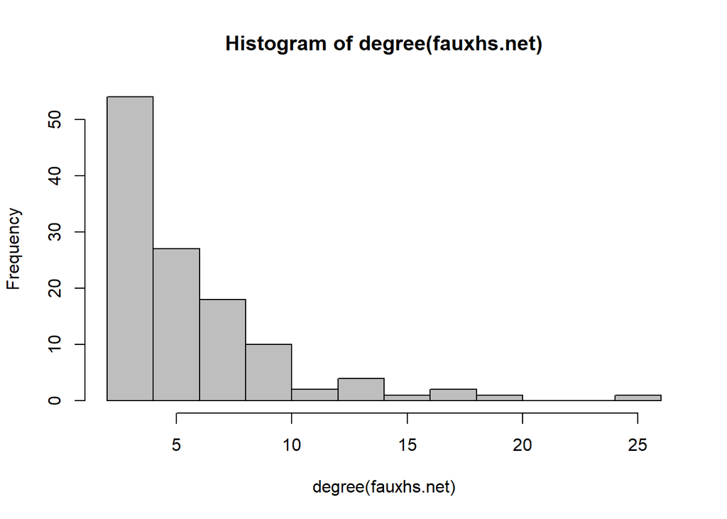

```r
hist(degree(fauxhs.net), breaks=10, col="gray")
```

```r
dyad_census(fauxhs.net)
```

```
## $mut
## [1] 185
##
## $asym
## [1] 0
##
## $null
## [1] 6955
```

```r
triad_census(fauxhs.net)
```

```
##  [1] 259598      0  20716      0      0      0      0      0      0      0
## [11]    464      0      0      0      0     62
```

```r
g.cluster <- transitivity(fauxhs.net, "global")
g.cluster
```

```
## [1] 0.2861538
```

```r
l.cluster <- transitivity(fauxhs.net, "local")
l.cluster
```

```
##   [1] 0.03384615 0.03571429 0.00000000 0.20000000 0.03571429 0.16666667
##   [7] 0.00000000 0.10714286 0.00000000 0.07142857 0.00000000 0.00000000
##  [13] 0.09090909 0.05494505 0.16666667 0.10714286 0.16666667 0.00000000
##  [19] 0.00000000 0.00000000 0.00000000 0.13333333 0.13333333 0.03267974
##  [25] 0.13333333 0.07142857 0.16666667 0.06666667 0.03921569 0.00000000
##  [31] 0.00000000 0.06666667 0.16666667 0.06666667 0.00000000 0.08888889
##  [37] 0.16666667 0.07142857 0.06666667 0.00000000 0.04444444 0.00000000
##  [43] 0.16666667 0.16666667 0.00000000 0.08888889 0.00000000 0.16666667
##  [49] 0.00000000 0.05263158 0.16666667 0.00000000 0.17857143 0.08791209
##  [55] 0.20000000 0.06666667 0.00000000 0.07142857 0.08888889 0.16666667
##  [61] 0.06666667 0.00000000 0.11111111 0.00000000 0.13333333 0.06666667
##  [67] 0.00000000 0.07692308 0.06666667 0.00000000 0.06666667 0.06666667
##  [73] 0.00000000 0.00000000 0.04444444 0.07142857 0.06666667 0.06060606
##  [79] 0.02222222 0.06666667 0.00000000 0.00000000 0.00000000 0.00000000
##  [85] 0.03571429 0.16666667 0.00000000 0.00000000 0.14285714 0.10714286
##  [91] 0.04166667 0.00000000 0.20000000 0.00000000 0.00000000 0.00000000
##  [97] 0.14285714 0.00000000 0.00000000 0.00000000 0.07142857 0.00000000
## [103] 0.06666667 0.04444444 0.00000000 0.00000000 0.06593407 0.03571429
## [109] 0.16666667 0.00000000 0.06666667 0.13333333 0.00000000 0.00000000
## [115] 0.00000000 0.00000000 0.16666667 0.00000000 0.00000000 0.00000000
```

```r
av.l.cluster <- transitivity(fauxhs.net, "localaverage")
av.l.cluster
```

[output not shown]

## Community detection

僅適用Undirected的網絡資料

```r
fauxhs.net1 <- graph_from_adjacency_matrix(fauxhs.mat, mode="undirected", weighted = T)
```

```r
com <- cluster_louvain(fauxhs.net1)
com
```

```
## IGRAPH clustering multi level, groups: 10, mod: 0.77
## + groups:
##   $`1`
##    [1] "4"   "9"   "12"  "16"  "19"  "21"  "32"  "37"  "59"  "62"  "67"  "69"
##   [13] "79"  "80"  "83"  "91"  "92"  "95"  "111"
##
##   $`2`
##   [1] "6"   "23"  "27"  "41"  "48"  "75"  "99"  "118"
##
##   $`3`
##   [1] "5"   "11"  "28"  "66"  "81"  "120"
##
##   + ... omitted several groups/vertices
```

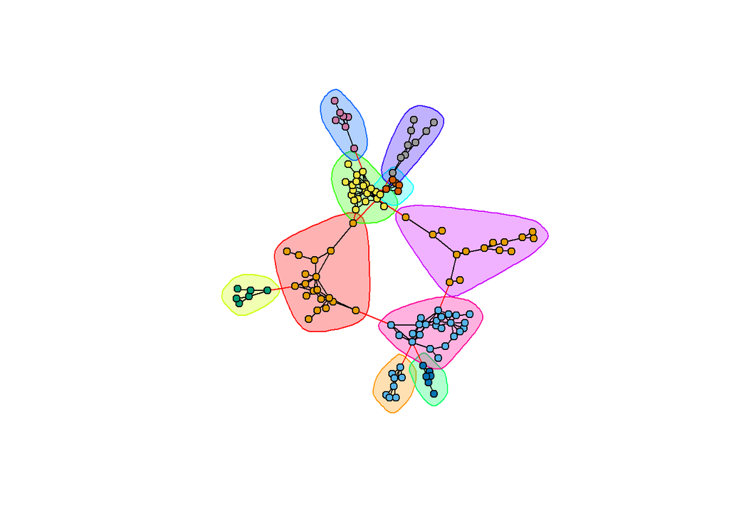

```r
plot(com, fauxhs.net1, vertex.label="", vertex.size=5, edge.width=E(fauxhs.net1)$weight, layout = fauxhs.layout)
```